# Analysis of Robbery Rates in Washington D.C: Identifying Factors that Influence Police Efficiency and Severity of Robbery

Muhannad Alwhebie, Liang Gao, Nammin Woo

2023-05-03

## I. Introduction

This project aims to build upon the previous exploratory data analysis project that examined the impact of COVID-19 lockdown on robbery rates in Washington D.C. In this project, our objective is to identify factors that influence police efficiency and severity of robbery crime. To gain a more comprehensive understanding of the underlying factors affecting robbery rates, we plan to incorporate demographic and economic data from the Census Bureau, such as median household income, poverty rate, and education level, as predictor variables in our model.

We will use two target variables in our analysis: Target_Clearance_time (whether the robbery took longer to clear) and Target_robbery_method (whether the robbery involved a gun or another type of weapon). By analyzing the relationships between these target variables and other explanatory variables, we hope to gain insights into the factors that affect clearance time and the use of guns in robberies.

The previous project found changes in robbery frequency during the pandemic, with underlying socio-economic factors potentially contributing to the patterns. Additionally, it supported the findings of the Boman and Gallupe (2020) study that violent crime increased during the lockdown period, with a dramatic increase in the number of robberies during Autumn. By utilizing GLM models to answer SMART questions related to robbery rates, we aim to gain a deeper understanding of the underlying factors that affect robbery rates in Washington D.C and provide insights that can inform future policy decisions related to crime prevention and public safety.

**Goal of this project: Building models to identify factors that influence police efficiency and severity of robbery.**

**Our SMART questions for this project include:**

1. What are the most important features that influence the clearance time and severity of robbery methods?
2. How accurately can we predict the clearance time and method based on these features?

## II. Methodology

**Data Sourcing**:

The dataset used in this study was sourced from the Open Data DC repository, which contains roughly 8000 observations of robbery incidents in the District of Columbia between January 2019 and December 2022. In addition, we obtained the Economic Characteristics of DC Census Tracts surveyed by the U.S. government using the CENSUS_TRACT variable.

**Data Pre-processing:**

After obtaining the necessary data, we first aggregated the census bureau data to the original dataset to include economic characteristics. Next, we defined two target variables, Target_Clearance_time and Target_robbery_method, which represent whether the robbery took longer to clear and whether a gun was used or not, respectively. We then conducted exploratory data analysis (EDA) to gain insights into the data and performed pre-processing to prepare the data for predictive modeling.

**Feature Selection:**

We used correlation analysis to identify the features that have the strongest relationship with the target variables. We also performed EDA on the target variables to understand their distribution and behavior with respect to the candidate features.

Overall, the methodology used in this study involved data sourcing, preprocessing and feature selection. The inclusion of economic characteristics data and the use of machine learning techniques can help to provide insights into the underlying factors that influence robbery rates in Washington D.C.

### Ⅰ. Data sourcing

We initially used the latest data in project 1, Robbery_clean. The outliers of clearance_rate have been removed (converted into NA).

```r
# the latest data of Project 1
#Robbery <-
#  readr::read_rds("Robbery_230303.Rds")

# the latest data of Project 1 (The outliers of clearance_rate have been removed (converted into NA))
#Robbery_clean <-
#  readr::read_rds("Robbery_clean_230303.Rds")


#Import data of project 2: started from Robbery_clean (added CENSUS_TRACT for aggregating census feature)
Robbery_clean_p2 = data.frame(read.csv("Robbery_clean_p2.csv"))
#Robbery_p2 = data.frame(read.csv("Robbery_p2.csv"))  #Data before cleansing outliers
Census_eco = data.frame(read.csv("ACS_Economic_Census_clean.csv"))
```

```r
#head(Robbery_clean_p2,5)
xkabledply(Robbery_clean_p2[1:4,], title = "First Four Rows of initial main Data (Robbery)")
```

First Four Rows of initial main Data (Robbery)

| OBJECTID | Seq | OFFENSE | REPORT_DAT | REPORT_DAT_2 | Period_cat | Period_cat_2 | Year | Month | Month_2 | Month_3 | Season | Date | Date_cat | Time_hour | SHIFT | Day_cat | Day_cat_2 | METHOD | DISTRICT | PSA | START_DATE | END_DATE | Clearance_rate | Period_cat_num | CENSUS_TRACT | CCN |
| --- | --- | --- | --- | --- | --- | --- | --- | --- | --- | --- | --- | --- | --- | --- | --- | --- | --- | --- | --- | --- | --- | --- | --- | --- | --- | --- |
| 293676435 | 1 | ROBBERY | 2019/01/01 07:53:38+00 | 1/1/2019 | Pre | Pre_1 | 2019 | 1 | 19_1 | Jan-19 | WINTER | 1 | Begin | 7 | MIDNIGHT | 3 | Weekday | GUN | 5 | 503 | 2019-01-01 7:14 | NA | NA | 1 | 11100 | 19000125 |
| 293907395 | 2 | ROBBERY | 2019/01/01 08:50:09+00 | 1/1/2019 | Pre | Pre_1 | 2019 | 1 | 19_1 | Jan-19 | WINTER | 1 | Begin | 8 | MIDNIGHT | 3 | Weekday | OTHERS | 5 | 507 | 2019-01-01 8:00 | 2019-01-01 8:06 | 6 | 1 | 7901 | 19000160 |
| 293676443 | 3 | ROBBERY | 2019/01/01 11:54:54+00 | 1/1/2019 | Pre | Pre_1 | 2019 | 1 | 19_1 | Jan-19 | WINTER | 1 | Begin | 11 | MIDNIGHT | 3 | Weekday | OTHERS | 5 | 502 | 2019-01-01 10:38 | NA | NA | 1 | 8701 | 19000248 |
| 293904185 | 4 | ROBBERY | 2019/01/01 20:21:41+00 | 1/1/2019 | Pre | Pre_1 | 2019 | 1 | 19_1 | Jan-19 | WINTER | 1 | Begin | 20 | EVENING | 3 | Weekday | GUN | 7 | 708 | 2019-01-01 18:16 | 2019-01-01 20:11 | 116 | 1 | 9811 | 19000401 |

Following 10 original features were mainly used as predictors in this project 2.

And to help with predictive modeling, we decided to add a few new features that come from the Census. This is census Tracts data that we will add on to original dataset.

```r
#head(Robbery_clean_p2,5)
xkabledply(Census_eco[1:4,], title = "First Four Rows of Census Tracts Dataframe")
```

First Four Rows of Census Tracts Dataframe

| OBJECTID | STATEFP | COUNTYFP | CENSUS_TRACT | GEOID | pop_16_over_emp_status | unemployment_rate | labor_forces_rate | armed_forces_rate | females_employed_rate | hs_own_children_under_6_pct | hs_own_children_under_6_labor_force_pct | hs_own_children_6_to_17_pct | hs_own_children_6_to_17_labor_force_pct | workers_16_over | drove_alone_pct | carpooled_pct | public_transportation_pct | walked_pct | other_means_pct | worked_from_home_pct | mean_travel_time | management_business_science_arts_occupations_pct | service_occupations_pct | Sales_and_office_occupations_pct | Natural_resources_construction_and_maintenance_occupations_pct | Production_transportation_and_material_moving_occupations_pct | Agriculture_forestry_fishing_and_hunting_and_mining_pct | Construction_pct | Manufacturing_pct | … |
| --- | --- | --- | --- | --- | --- | --- | --- | --- | --- | --- | --- | --- | --- | --- | --- | --- | --- | --- | --- | --- | --- | --- | --- | --- | --- | --- | --- | --- | --- | --- |
| 1 | 11 | 1 | 1902 | 11001001902 | 1882 | 7.3 | 66.4 | 0.00 | 90.32258065 | 25.92592593 | 21.99074074 | 32.29166667 | 20.94907407 | 1156 | 0.410 | 0.0467 | 0.183 | 0.0242 | 0.0208 | 0.315 | 33.7 | 65.3 | 12.08 | 13.37 | 4.573 | 4.659 | 0.000 | 3.624 | 0.000 | … |
| 2 | 11 | 1 | 5001 | 11001005001 | 1827 | 2.2 | 85.8 | 0.00 | 98.19277108 | 3.631284916 | 3.631284916 | 5.2141527 | 5.2141527 | 1534 | 0.111 | 0.0235 | 0.217 | 0.3435 | 0.1245 | 0.181 | 27.8 | 87.7 | 4.04 | 7.43 | 0.261 | 0.521 | 0.000 | 0.782 | 0.000 | … |
| 3 | 11 | 1 | 9807 | 11001009807 | 2729 | 14.0 | 67.4 | 0.00 | 90.48751486 | 25.57275542 | 25.57275542 | 23.77708978 | 17.70897833 | 1538 | 0.488 | 0.1053 | 0.306 | 0.0000 | 0.0000 | 0.101 | 55.7 | 34.8 | 44.06 | 13.27 | 3.350 | 4.551 | 0.758 | 1.327 | 0.822 | … |
| 4 | 11 | 1 | 9802 | 11001009802 | 1404 | 40.0 | 40.6 | 2.98 | 71.50537634 | 14.98216409 | 12.60404281 | 29.60760999 | 17.12247325 | 349 | 0.398 | 0.0401 | 0.499 | 0.0000 | 0.0630 | 0.000 | 45.2 | 25.6 | 25.60 | 36.45 | 8.735 | 3.615 | 0.000 | 0.000 | 4.217 | … |

All robbery records in our dataset have its own location information that the robberies are occurred. We already used location variable `DISTRICT` in project 1 meaning Police Service Area, and additionally used location variable `CENSUS_TRACT` meaning statistical subdivisions of a county.(Population from 1,200 to 1,800)

Specifically, we used the **specific Economic Characteristics of DC Census Tracts** that are surveyed from U.S government instead of directly using `CENSUS_TRACT`.

Economic Characteristics are about Employment, Commuting, Occupation, Income, Health Insurance, Poverty,etc., and it is based on the most current release of data from the American Community Survey (ACS) about economic characteristics. (2020 Census Tract boundaries).

All Census features were Wrangled through follows:  - Checked basic things of each feature (existence of NaN, distribution,etc.) - Name of features were changed for being easily recognized for analysis. - Considering purpose of analysis, all features are re-scaled as proportion and dummified (ex. percentage of workers who are using carpool for commuting) or summarized (Mean, Median).

```r
#columns that are necessary to anaysis
#ex_cols <- c('OBJECTID','STATEFP','COUNTYFP','CENSUS_TRACT','GEOID')
#temp <- select(Census_eco,-OBJECTID,-STATEFP,-COUNTYFP,-CENSUS_TRACT,-GEOID)
#knitr::kable(temp, format = "markdown", caption="Overall summary statistics of DC Census Tract(Economic Characteristics)")
```

Census features were aggregated to initial main data by the key of `CENSUS_TRACT`.

```r
#Add new features joining with key
temp <- select(Census_eco,-OBJECTID,-STATEFP,-COUNTYFP,-GEOID)
Robbery_clean_p2_add <- merge(x = Robbery_clean_p2, y = temp, by = "CENSUS_TRACT", all.x = TRUE)
```

```r
#count(Robbery_clean_p2,SHIFT)
#head(temp,5)
nrow(Robbery_clean_p2)
nrow(Robbery_clean_p2_add)
ncol(Robbery_clean_p2) #Before aggregation
ncol(Census_eco)-5     #Census
ncol(Robbery_clean_p2_add) #After aggregation(add Cesnsus)
```

### Ⅱ. Define target variables

The second target variable we will define is `Target_robbery_method.` This variable will indicate whether the robbery was committed with a gun or with some other weapon or no weapon at all. We will use the “Gun” variable from the dataset to determine the robbery method. If the weapon used was a gun, the value for Target_robbery_method will be 1, indicating that the robbery was committed with a gun. If the weapon used was anything else, the value for `Target_robbery_method` will be 0, indicating that the robbery was committed with some other weapon or no weapon at all.

By defining these two target variables, we can build predictive models that will allow us to identify the factors that contribute to longer clearance times and gun-related robberies. We can then use this information to develop strategies for reducing these types of crimes in Washington D.C.

```r
#Summary
#columns to analyse
cols <- c('Clearance_rate','METHOD')
#summary(select(Robbery,cols))
#summary(select(Robbery_clean_p2_add,cols))

knitr::kable(summary(select(Robbery_clean_p2_add,cols)), format = "markdown", caption="T1.Summary statistics of Target variables")
```

T1.Summary statistics of Target variables

|  | Clearance_rate | METHOD |
| --- | --- | --- |
|  | Min. : 0 | Length:8343 |
|  | 1st Qu.: 5 | Class :character |
|  | Median : 30 | Mode :character |
|  | Mean : 49 | NA |
|  | 3rd Qu.: 84 | NA |
|  | Max. :222 | NA |
|  | NA’s :2005 | NA |

**1. `Target_Clearance_time` implies Efficiency of Police or Difficulty of incident, whether need Longer time to clear or not.**

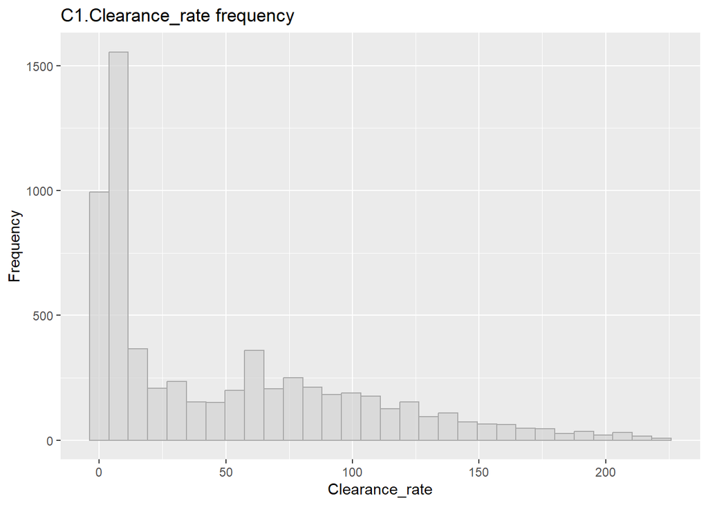

```r
plot <- ggplot(data=Robbery_clean_p2_add, aes(Clearance_rate)) +
  geom_histogram(col="darkgrey",
                 fill="lightgrey",
                 alpha = .7,bins = 30) +
  labs(x="Clearance_rate", y="Frequency") +
  labs(title="C1.Clearance_rate frequency")
plot
```

```r
#TWO var Groupby(mean of target by X category groups)
temp <-  Robbery_clean_p2_add %>% group_by(DISTRICT) %>%
                   summarise(avg = mean(Clearance_rate, na.rm = TRUE),.groups = 'drop')  #Targe(%): mean( as.numeric(Target_Clearance_time)

arrange(temp, DISTRICT)
```

```
## # A tibble: 8 × 2
##   DISTRICT   avg
##      <int> <dbl>
## 1        1  37.7
## 2        2  36.0
## 3        3  46.2
## 4        4  40.2
## 5        5  48.3
## 6        6  65.2
## 7        7  63.2
## 8       NA  48.5
```

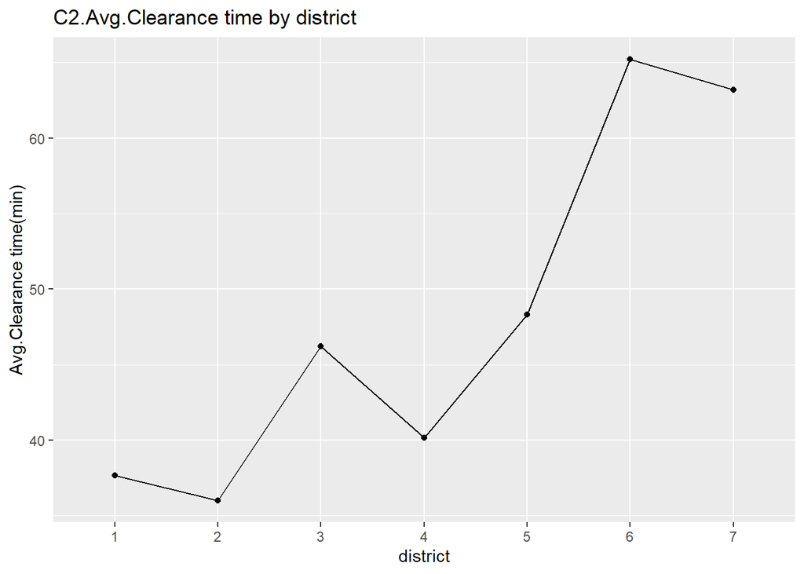

```r
temp_gr <- data.frame(temp)

#Make chart (scatter)
plot <- ggplot(temp_gr, aes(DISTRICT, avg)) + geom_line() + labs(x="district", y="Avg.Clearance time(min)") +
  labs(title="C2.Avg.Clearance time by district") + scale_x_discrete(limits=c("1","2","3","4","5","6","7")) + geom_point() #with 3-D: ggplot(temp_gr, aes(x, y, colour = Period_cat))

plot
```

Chart C1 shows `Clearance_rate` is highly right skewed, and Chart C2 displaying `avg.Clearance_time` per `DISTRICT` exhibits clearance time of robbery visually distinguished by the threshold 40~50 min(similar to average). So, We defined Long clearance time as over 40 min and short clearance time as less than 40 min.

```r
#Final target
Robbery_clean_p2_add$Target_Clearance_time_f <- ifelse(Robbery_clean_p2_add$Clearance_rate >= 40,
c(1), c(0))

#This one is optional (over Q3)
Robbery_clean_p2_add$Target_Clearance_time <- ifelse(Robbery_clean_p2_add$Clearance_rate >= 85,
c(1), c(0))

#This one is optional (GUN&Clear)
Robbery_clean_p2_add$Target_clr_gun <- ifelse((Robbery_clean_p2_add$Target_Clearance_time_f ==1) & (Robbery_clean_p2_add$METHOD =='GUN'), c(1),c(0))


count(Robbery_clean_p2_add,Target_Clearance_time_f, sort=FALSE)
```

```
##   Target_Clearance_time_f    n
## 1                       0 3441
## 2                       1 2897
## 3                      NA 2005
```

Our first modeling target, `Target_Clearance_time` has three levels as follows:

- `Target_Clearance_time`=1 : Need long time, more than 40 min
- `Target_Clearance_time`=0 : Need short time, less than 40 min
- NA: `Outliers` (Need extremely long time (avg 2.5 days).

**2. `Target_robbery_method` indicates Severity of robbery, whether firearm, Gun was used or not.**

```r
# 1
Robbery_clean_p2_add$Target_robbery_method <- ifelse(Robbery_clean_p2_add$METHOD == 'GUN',c(1), c(0))
count(Robbery_clean_p2_add,Target_robbery_method, sort=FALSE)
```

```
##   Target_robbery_method    n
## 1                     0 4312
## 2                     1 4031
```

Our second modeling target, `Target_robbery_method` has two levels as follows:

- `Target_robbery_method`=1 : Gun was used for robbery.
- `Target_robbery_method`=0 : Knife or Other weapons were used,

```r
#Temporary Saved current data.

#Dataframe Save and load
#readr::write_rds(Robbery_clean_p2_add, "Robbery_clean_p2_add.Rds")

#Can load the dataset of this stage by letting active below code
#Robbery_clean_p2_add <-
#  readr::read_rds("Robbery_clean_p2_add.Rds")
```

### Ⅲ. Pre-processing for predictive modeling

From this section, we will check only input/target variables that are used for modeling.

Check data type of original variables (With or Without Census Track)

**1. Revise/Add features**

1. In terms of using `Period_cat_num` to precis target, we simplified the period into two categories (Lock-down=1, other=0).

```r
attach(Robbery_clean_p2_add)
Robbery_clean_p2_add$Period_cat_num_2[Period_cat == 'Pre'] <- 0
Robbery_clean_p2_add$Period_cat_num_2[Period_cat == 'Lock'] <- 1
Robbery_clean_p2_add$Period_cat_num_2[Period_cat  == 'Post'] <- 0
detach(Robbery_clean_p2_add)
#summary(Robbery_clean_p2_add$Period_cat_num_2)
```

2. `Hour` Start time of police clearance was created.

```r
#colnames(Robbery_clean_p2_model)
library(lubridate)
#head(Robbery_clean_p2_add$START_DATE,5)
Robbery_clean_p2_add$Hour <- hour(Robbery_clean_p2_add$START_DATE)
```

```r
co = c('START_DATE','Hour')
head(select(Robbery_clean_p2_add,co),5)
```

Types of original predictors (w.o Census) are below. Some categorical features needs to be **converted into Factor**. for logistic regression.

```r
col_org <- c('Date_cat','Day_cat','Day_cat_2','DISTRICT','Month','Period_cat_num_2','Season','SHIFT','Hour','METHOD')

str(select(Robbery_clean_p2_add,col_org))
```

```
## 'data.frame':    8343 obs. of  10 variables:
##  $ Date_cat        : chr  "End" "Middle" "Middle" "Begin" ...
##  $ Day_cat         : int  3 6 3 1 2 2 2 1 1 3 ...
##  $ Day_cat_2       : chr  "Weekday" "Weekday" "Weekday" "Weekend" ...
##  $ DISTRICT        : int  6 7 2 2 2 2 2 2 2 2 ...
##  $ Month           : int  10 10 10 9 10 4 11 9 11 7 ...
##  $ Period_cat_num_2: num  0 0 0 1 1 0 0 1 1 0 ...
##  $ Season          : chr  "AUTUMN" "AUTUMN" "AUTUMN" "AUTUMN" ...
##  $ SHIFT           : chr  "DAY" "DAY" "EVENING" "MIDNIGHT" ...
##  $ Hour            : int  19 13 23 3 18 3 6 3 3 0 ...
##  $ METHOD          : chr  "OTHERS" "GUN" "OTHERS" "GUN" ...
```

```r
#sum_list <- summary(Robbery_clean_p2_add)
#write.csv(sum_list, "sum_list.csv", row.names=FALSE)
```

**2. Change data types of features**

1. So, a few categorical variables including targets were Changed into factor.

```r
cols <- c('Date_cat','Day_cat_2','Season','SHIFT','METHOD','Period_cat_num_2','Target_Clearance_time_f','Target_robbery_method')
#array
Robbery_clean_p2_add %<>%
       mutate_each_(funs(factor(.)),cols)

str(select(Robbery_clean_p2_add,cols))
```

```
## 'data.frame':    8343 obs. of  8 variables:
##  $ Date_cat               : Factor w/ 3 levels "Begin","End",..: 2 3 3 1 2 2 3 3 1 2 ...
##  $ Day_cat_2              : Factor w/ 2 levels "Weekday","Weekend": 1 1 1 2 1 1 1 2 2 1 ...
##  $ Season                 : Factor w/ 4 levels "AUTUMN","SPRING",..: 1 1 1 1 1 2 1 1 1 3 ...
##  $ SHIFT                  : Factor w/ 3 levels "DAY","EVENING",..: 1 1 2 3 2 3 3 3 3 2 ...
##  $ METHOD                 : Factor w/ 3 levels "GUN","KNIFE",..: 3 1 3 1 1 3 1 1 1 1 ...
##  $ Period_cat_num_2       : Factor w/ 2 levels "0","1": 1 1 1 2 2 1 1 2 2 1 ...
##  $ Target_Clearance_time_f: Factor w/ 2 levels "0","1": NA 2 1 2 2 1 1 2 1 1 ...
##  $ Target_robbery_method  : Factor w/ 2 levels "0","1": 1 2 1 2 2 1 2 2 2 2 ...
```

B. And a few Census features were converted into numeric.

```r
#15 vars
cols <- c('females_employed_rate','hs_10000_to_14999_pct','hs_100000_to_149999_pct','hs_15000_to_24999_pct','hs_150000_to_194999_pct','hs_200000__pct','hs_25000_to_34999_pct','hs_35000_to_49999_pct','hs_50000_to_74999_pct','hs_75000_to_99999_pct','hs_Less_than_10000_pct','hs_own_children_6_to_17_labor_force_pct','hs_own_children_6_to_17_pct','hs_own_children_under_6_labor_force_pct','hs_own_children_under_6_pct')  #array
Robbery_clean_p2_add[cols] <- sapply(Robbery_clean_p2_add[cols],as.numeric)
#str(select(Robbery_clean_p2_add,cols))
```

Finally, The dataset consists of 111 variables. including 78 Census Economic Characteristics features.

```r
nrow(Robbery_clean_p2_add)    #Census
ncol(Robbery_clean_p2_add) #After aggregation(add Cesnsus)
#str(Robbery_clean_p2_add)
```

```r
#Dataframe Save and load
#readr::write_rds(Robbery_clean_p2_add, "Robbery_clean_p2_model.Rds")

#Can load the dataset of this stage by letting active below code
#Robbery_clean_p2_model <-
#  readr::read_rds("Robbery_clean_p2_model.Rds")
```

**3-1.Finalize defining modeling data 2 for `Target_robbery_method`**

```r
#count(Robbery_clean_p2_add,Target_robbery_method, sort=FALSE)

  cols_m2 <- c('Target_robbery_method','Hour','Date_cat','Day_cat','Day_cat_2','DISTRICT','Month','Period_cat_num_2','Season','SHIFT','Agriculture_forestry_fishing_and_hunting_and_mining_pct','armed_forces_rate','Arts_entertainment_and_recreation_and_accommodation_and_food_services_pct','carpooled_pct','Construction_pct','drove_alone_pct','Earning_mean','Earning_median_fmale_wk','Earning_median_male_wk','Earning_median_wk','Educational_services_and_health_care_and_social_assistance_pct','females_employed_rate','Finance_and_insurance_and_real_estate_and_rental_and_leasing_pct','Government_workers_pct','hs_10000_to_14999_pct','hs_100000_to_149999_pct','hs_15000_to_24999_pct','hs_150000_to_194999_pct','hs_200000__pct','hs_25000_to_34999_pct','hs_35000_to_49999_pct','hs_50000_to_74999_pct','hs_75000_to_99999_pct','hs_Less_than_10000_pct','hs_own_children_6_to_17_labor_force_pct','hs_own_children_6_to_17_pct','hs_own_children_under_6_labor_force_pct','hs_own_children_under_6_pct','Income_mean','Income_median','Information_pct','labor_forces_rate','management_business_science_arts_occupations_pct','Manufacturing_pct','mean_travel_time','Natural_resources_construction_and_maintenance_occupations_pct','other_means_pct','Other_services_except_public_administration_pct','pct_all_families_below_poverty','pct_all_families_related_children_below18_below_poverty','pct_all_families_related_children_below5_below_poverty','pct_all_people_18plus_below_poverty','pct_all_people_18to64_below_poverty','pct_all_people_65plus_below_poverty','pct_all_people_below_poverty','pct_all_people_related_children_under18_5to17_below_poverty','pct_all_people_related_children_under18_below_poverty','pct_all_people_related_children_under18_below5_below_poverty','pct_all_people_under18_below_poverty','pct_below_poverty_female_no_spouse_present','pct_below_poverty_female_no_spouse_present_related_children_below18','pct_female_no_spouse_present_related_children_below18_below5_below_poverty','pct_married_couple_families_below_poverty','pct_married_couple_families_related_children_below18_below_poverty','pct_married_couple_families_related_children_below5_below_poverty','pct_people_in_families_below_poverty','pct_unrelated_individuals_15plus_below_poverty','pop_16_over_emp_status','Private_wage_and_salary_workers_pct','Production_transportation_and_material_moving_occupations_pct','Professional_scientific_and_management_and_administrative_and_waste_management_services_pct','Public_administration_pct','public_assistance_income_mean','public_transportation_pct','Retail_trade_pct','Retirement_income_mean','Sales_and_office_occupations_pct','Self_employed_in_own_not_incorporated_business_workers_pct','service_occupations_pct','Social_Security_income_mean','Supplemental_Security_income_mean','Transportation_and_warehousing_and_utilities_pct','unemployment_rate','Unpaid_family_workers_pct','walked_pct','Wholesale_trade_pct','worked_from_home_pct','workers_16_over')

model_2_clean <- select(Robbery_clean_p2_add,cols_m2)
#str(model_2_clean)
```

To finalize modeling data 2 for `Target_robbery_method`,

- The dataset has 8343 observations same as the initial dataset,
- and 87 features and 1 target variable after excluding needless columns for modeling.

```r
nrow(model_2_clean)    #Census
ncol(model_2_clean) #After aggregation(add Cesnsus)
#str(model_2_clean)
```

```r
#Dataframe Save and load
#readr::write_rds(model_2_clean, "Robbery_clean_p2_model_2.Rds")

#Can load the dataset of this stage by letting active below code
#model_2_clean <- readr::read_rds("Robbery_clean_p2_model_2.Rds")
```

**3-2.Finalize defining modeling data 1 for `Target_Clearance_time`**

```r
cols_m1 <- c('Clearance_rate','Target_Clearance_time_f','Hour','Date_cat','Day_cat','Day_cat_2','DISTRICT','Month','Period_cat_num_2','Season','SHIFT','METHOD','Agriculture_forestry_fishing_and_hunting_and_mining_pct','armed_forces_rate','Arts_entertainment_and_recreation_and_accommodation_and_food_services_pct','carpooled_pct','Construction_pct','drove_alone_pct','Earning_mean','Earning_median_fmale_wk','Earning_median_male_wk','Earning_median_wk','Educational_services_and_health_care_and_social_assistance_pct','females_employed_rate','Finance_and_insurance_and_real_estate_and_rental_and_leasing_pct','Government_workers_pct','hs_10000_to_14999_pct','hs_100000_to_149999_pct','hs_15000_to_24999_pct','hs_150000_to_194999_pct','hs_200000__pct','hs_25000_to_34999_pct','hs_35000_to_49999_pct','hs_50000_to_74999_pct','hs_75000_to_99999_pct','hs_Less_than_10000_pct','hs_own_children_6_to_17_labor_force_pct','hs_own_children_6_to_17_pct','hs_own_children_under_6_labor_force_pct','hs_own_children_under_6_pct','Income_mean','Income_median','Information_pct','labor_forces_rate','management_business_science_arts_occupations_pct','Manufacturing_pct','mean_travel_time','Natural_resources_construction_and_maintenance_occupations_pct','other_means_pct','Other_services_except_public_administration_pct','pct_all_families_below_poverty','pct_all_families_related_children_below18_below_poverty','pct_all_families_related_children_below5_below_poverty','pct_all_people_18plus_below_poverty','pct_all_people_18to64_below_poverty','pct_all_people_65plus_below_poverty','pct_all_people_below_poverty','pct_all_people_related_children_under18_5to17_below_poverty','pct_all_people_related_children_under18_below_poverty','pct_all_people_related_children_under18_below5_below_poverty','pct_all_people_under18_below_poverty','pct_below_poverty_female_no_spouse_present','pct_below_poverty_female_no_spouse_present_related_children_below18','pct_female_no_spouse_present_related_children_below18_below5_below_poverty','pct_married_couple_families_below_poverty','pct_married_couple_families_related_children_below18_below_poverty','pct_married_couple_families_related_children_below5_below_poverty','pct_people_in_families_below_poverty','pct_unrelated_individuals_15plus_below_poverty','pop_16_over_emp_status','Private_wage_and_salary_workers_pct','Production_transportation_and_material_moving_occupations_pct','Professional_scientific_and_management_and_administrative_and_waste_management_services_pct','Public_administration_pct','public_assistance_income_mean','public_transportation_pct','Retail_trade_pct','Retirement_income_mean','Sales_and_office_occupations_pct','Self_employed_in_own_not_incorporated_business_workers_pct','service_occupations_pct','Social_Security_income_mean','Supplemental_Security_income_mean','Transportation_and_warehousing_and_utilities_pct','unemployment_rate','Unpaid_family_workers_pct','walked_pct','Wholesale_trade_pct','worked_from_home_pct','workers_16_over')

model_1_clean <- select(Robbery_clean_p2_add,cols_m1)
model_1_clean <-  subset(model_1_clean, Target_Clearance_time_f == 0 |Target_Clearance_time_f == 1)
#str(model_1_clean)
nrow(model_1_clean)
ncol(model_1_clean)
count(model_1_clean,Target_Clearance_time_f, sort=FALSE)
```

To finalize modeling data 1 for `Target_Clearance_time_f`,

- The dataset has 6338 observations, excluded **outliers of Clearance_rate** (having Target_Clearance_time_f =Na). In project 1, outliers that have extremely large value were converted into Na (By unusual Observations test using `outlierKD2`).
- And, it has 88 features and 1 target variable after excluding needless columns for modeling. (`METHOD` also could be used as predictor for model 1).

```r
#Dataframe Save and load
#readr::write_rds(model_1_clean, "Robbery_clean_p2_model_1.Rds")

#Can load the dataset of this stage by letting active below code
#model_1_clean <- readr::read_rds("Robbery_clean_p2_model_1.Rds")
```

### Ⅳ. Feature Selection (Step 1 of the modeling)

**From this section, candidate features were chosen for initial model by examining relationship with target variables, `Target_Clearance_time_f` and `Target_robbery_method` by examining relationship with independent vars.**

**1. Model 1 (`Target_Clearance_time_f`)**

- 1. Since `Target_Clearance_time_f` came from **Ratio variable, `Clearance_time` that refers duration**, The Box Plots or summarized plots of `Clearance_time` were showed for a few categorical features.
- 2. In terms of interval variables such as Census, Histograms split by the target groups were used for checking relationship.

Finally, **Correlation plots** were used for feature selection.

- For categorical features, we used correlations only for relatively comparing the linear relationship with target.
- Hypothesis tests (Chi-square) were additionally conducted for getting statistical clues.
- For continuous features, correlations were used to filter highly correlated predictors to prevent a multicollinearity.

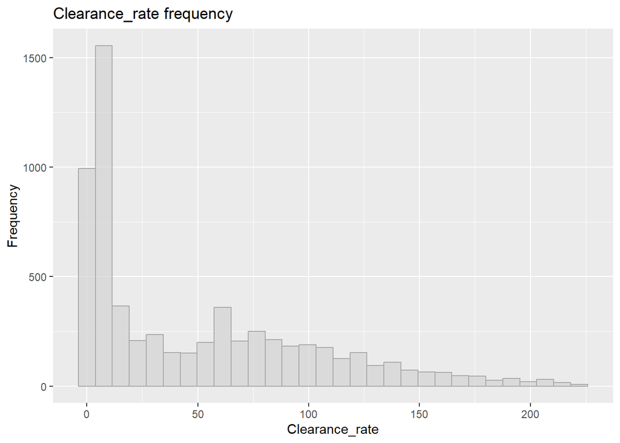

```r
plot <- ggplot(data=model_1_clean, aes(Clearance_rate)) +
  geom_histogram(col="darkgrey",
                 fill="lightgrey",
                 alpha = .7,bins = 30) +
  labs(x="Clearance_rate", y="Frequency") +
  labs(title="Clearance_rate frequency")
plot
```

A-1. (EDA-categorical features) Chart 3 indicates `avg.Clearance_time` per `DISTRICTS`.

- DISTRICTS seems to have explicit relationship with clearance time

```r
#TWO var Groupby(mean of target by X category groups)
temp <-  model_1_clean %>% group_by(DISTRICT) %>%
                   summarise(avg = mean(Clearance_rate, na.rm = TRUE),.groups = 'drop')  #Targe(%): mean( as.numeric(Target_Clearance_time)

arrange(temp, DISTRICT)
```

```
## # A tibble: 8 × 2
##   DISTRICT   avg
##      <int> <dbl>
## 1        1  37.7
## 2        2  36.0
## 3        3  46.2
## 4        4  40.2
## 5        5  48.3
## 6        6  65.2
## 7        7  63.2
## 8       NA  48.5
```

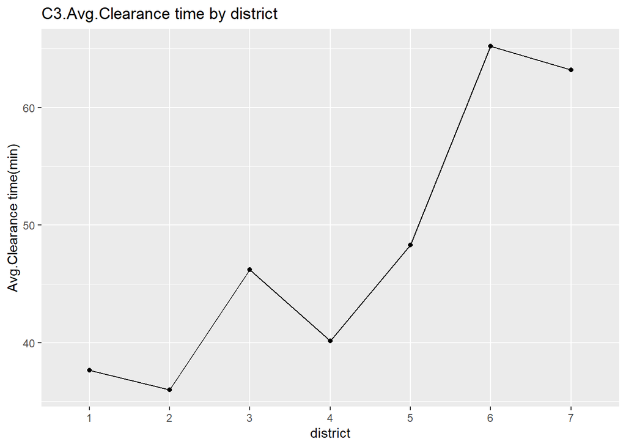

```r
temp_gr <- data.frame(temp)

#Make chart (scatter)
plot <- ggplot(temp_gr, aes(DISTRICT, avg)) + geom_line() + labs(x="district", y="Avg.Clearance time(min)") +
  labs(title="C3.Avg.Clearance time by district") + scale_x_discrete(limits=c("1","2","3","4","5","6","7")) + geom_point() #with 3-D: ggplot(temp_gr, aes(x, y, colour = Period_cat))

plot
```

This is the Chi-square test to identify independence with DISTRICT and Target_Clearance_time_f

```r
contable = table(model_1_clean$DISTRICT, model_1_clean$Target_Clearance_time_f)
chitest = chisq.test(contable)
chitest
```

```
##
##  Pearson's Chi-squared test
##
## data:  contable
## X-squared = 289, df = 6, p-value <0.0000000000000002
```

```r
#SHIFT.
contable = table(model_1_clean$SHIFT, model_1_clean$Target_Clearance_time_f)
chitest = chisq.test(contable)
chitest

#Period_cat_num_2
contable = table(model_1_clean$Period_cat_num_2, model_1_clean$Target_Clearance_time_f)
chitest = chisq.test(contable)
chitest
```

A-2. Chart 4 indicates distribution of `Clearance_time` per `Day_cat_2`.

- We identified clear time seems to slightly increased on weekend.

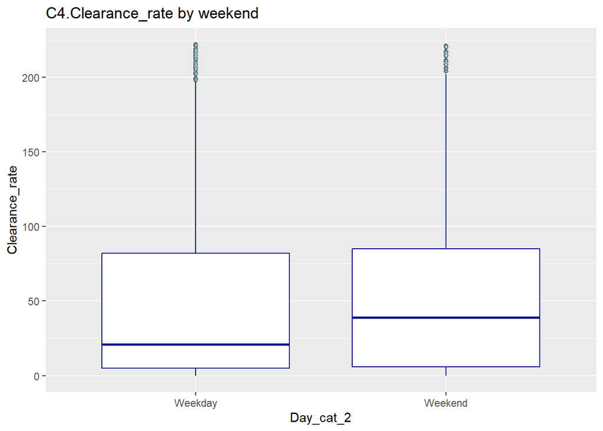

```r
box <- ggplot(model_1_clean, aes(y=Clearance_rate, x=Day_cat_2)) +
  geom_boxplot() +
  geom_boxplot( colour="darkblue", outlier.colour="lightblue", outlier.shape=8, outlier.size=1) +
  labs(title="C4.Clearance_rate by weekend",x="Day_cat_2", y = "Clearance_rate")
box
```

A-3. Chart 5 indicates distribution of `Clearance_time` per `SHIFT`.

- We identified clear time seems to slightly increased after the evening, midnight.

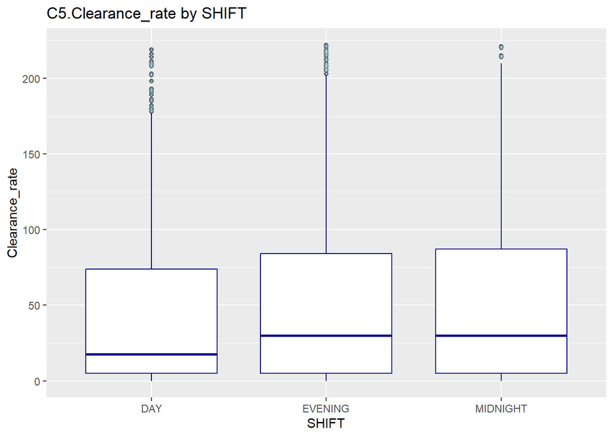

```r
box <- ggplot(model_1_clean, aes(y=Clearance_rate, x=SHIFT)) +
  geom_boxplot() +
  geom_boxplot( colour="darkblue", outlier.colour="lightblue", outlier.shape=8, outlier.size=1) +
  labs(title="C5.Clearance_rate by SHIFT",x="SHIFT", y = "Clearance_rate")
box
```

A-4. Chart 6 indicates `avg.Clearance_time` per `Month`.

- It seems to identify seasonality by additionally checking `Season`.

```r
temp <-  model_1_clean %>% group_by(Month) %>%
                   summarise(avg = mean(Clearance_rate, na.rm = TRUE),.groups = 'drop')  #Targe(%): mean( as.numeric(Target_Clearance_time)

arrange(temp, Month)
```

```
## # A tibble: 12 × 2
##    Month   avg
##    <int> <dbl>
##  1     1  47.4
##  2     2  48.4
##  3     3  50.4
##  4     4  52.4
##  5     5  48.1
##  6     6  49.3
##  7     7  49.4
##  8     8  51.0
##  9     9  51.3
## 10    10  51.3
## 11    11  46.6
## 12    12  48.5
```

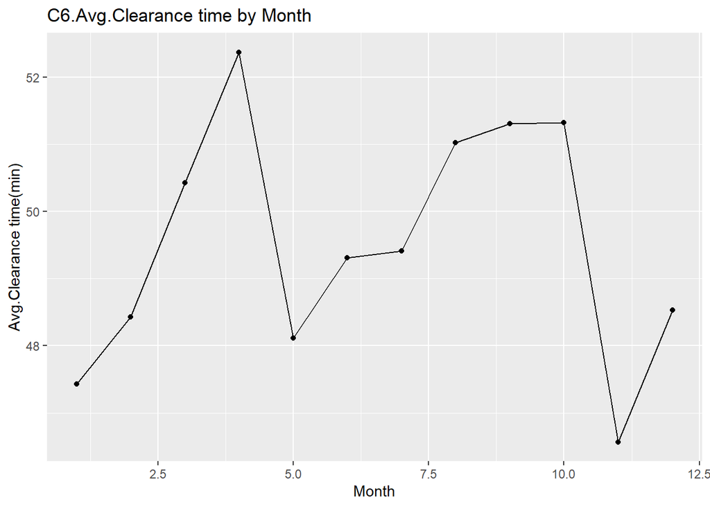

```r
temp_gr <- data.frame(temp)

#Make chart (scatter)
plot <- ggplot(temp_gr, aes(Month, avg)) + geom_line() + labs(x="Month", y="Avg.Clearance time(min)") +
  labs(title="C6.Avg.Clearance time by Month") + geom_point()

plot
```

A-5. Chart 7 indicates distribution of `Clearance_time` per `Season`.

- Clear time relatively decreased in winter season.

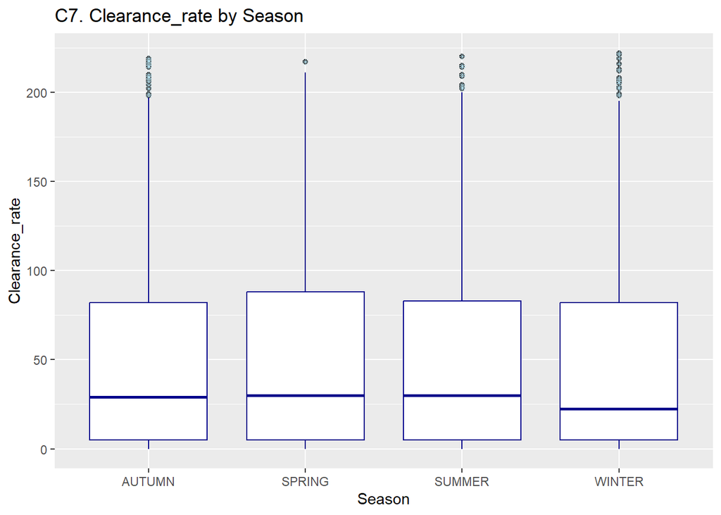

```r
box <- ggplot(model_1_clean, aes(y=Clearance_rate, x=Season)) +
  geom_boxplot() +
  geom_boxplot( colour="darkblue", outlier.colour="lightblue", outlier.shape=8, outlier.size=1) +
  labs(title="C7. Clearance_rate by Season",x="Season", y = "Clearance_rate")
box
```

A-6. Chart 8 indicates distribution of `Clearance_time` per `Period_cat_num_2`.

- In Lock-down period, clear time was increased implying some relationship with efficiency of police.

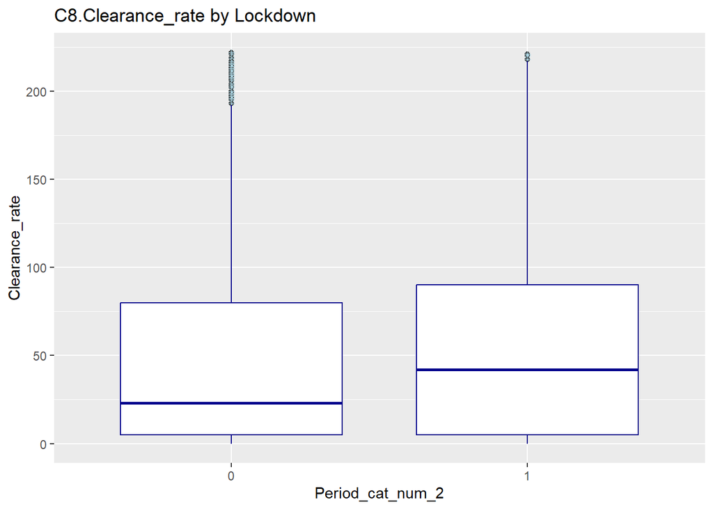

```r
box <- ggplot(model_1_clean, aes(y=Clearance_rate, x=Period_cat_num_2)) +
  geom_boxplot() +
  geom_boxplot( colour="darkblue", outlier.colour="lightblue", outlier.shape=8, outlier.size=1) +
  labs(title="C8.Clearance_rate by Lockdown",x="Period_cat_num_2", y = "Clearance_rate")
box
```

```r
contable = table(model_1_clean$Day_cat_2, model_1_clean$Target_Clearance_time_f)
chitest = chisq.test(contable)
chitest
```

```
##
##  Pearson's Chi-squared test with Yates' continuity correction
##
## data:  contable
## X-squared = 17, df = 1, p-value = 0.00004
```

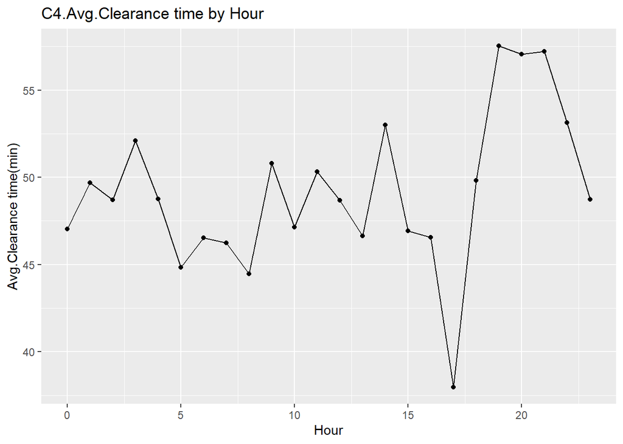

```r
#Reference- Not showing in the final report.
#Hour
temp <-  model_1_clean %>% group_by(Hour) %>%
                   summarise(avg = mean(Clearance_rate, na.rm = TRUE),.groups = 'drop')  #Targe(%): mean( as.numeric(Target_Clearance_time)

arrange(temp, Hour)
temp_gr <- data.frame(temp)

#Make chart (scatter)
plot <- ggplot(temp_gr, aes(Hour, avg)) + geom_line() + labs(x="Hour", y="Avg.Clearance time(min)") +
  labs(title="C4.Avg.Clearance time by Hour") + geom_point()

plot
```

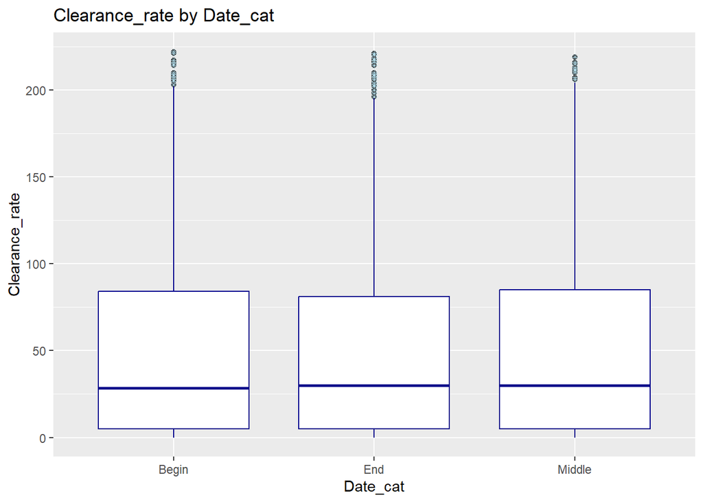

```r
#Date_cat
box <- ggplot(model_1_clean, aes(y=Clearance_rate, x=Date_cat)) +
  geom_boxplot() +
  geom_boxplot( colour="darkblue", outlier.colour="lightblue", outlier.shape=8, outlier.size=1) +
  labs(title="Clearance_rate by Date_cat",x="Date_cat", y = "Clearance_rate")
box
```

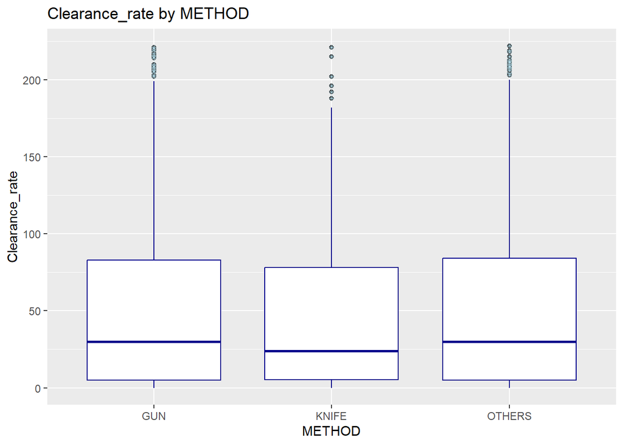

```r
#Method.
box <- ggplot(model_1_clean, aes(y=Clearance_rate, x=METHOD)) +
  geom_boxplot() +
  geom_boxplot( colour="darkblue", outlier.colour="lightblue", outlier.shape=8, outlier.size=1) +
  labs(title="Clearance_rate by METHOD",x="METHOD", y = "Clearance_rate")
box
```

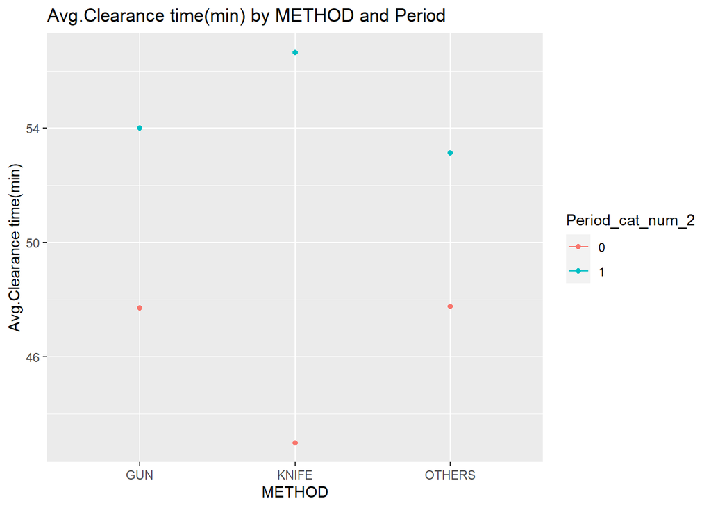

```r
#TWO var Groupby(mean of target by X category groups)= % of High Clearance_time
temp <-  model_1_clean %>% group_by(METHOD,Period_cat_num_2) %>%
                   summarise(avg = mean(Clearance_rate, na.rm = TRUE),.groups = 'drop')

arrange(temp, METHOD,Period_cat_num_2)

temp_gr <- data.frame(temp)

#Make chart (scatter)
plot_2 <- ggplot(temp_gr, aes(METHOD, avg, colour = Period_cat_num_2)) + geom_line() + labs(x="METHOD", y="Avg.Clearance time(min)") +
  labs(title="Avg.Clearance time(min) by METHOD and Period") + geom_point()

plot_2
```

```r
str(model_1_clean)
```

**A-7. Below is Correlation plots with original features and target (with out Census)**

- **The first row means the relationship between features and target.**
- District(Police Service Area), Period_cat_num_2, and SHIFT(Timezone of robberies) show relatively high correlation with Clearance_target, but it is small.
- Most origin variables will be initially used in the model except for a few features like Day_cat,etc.

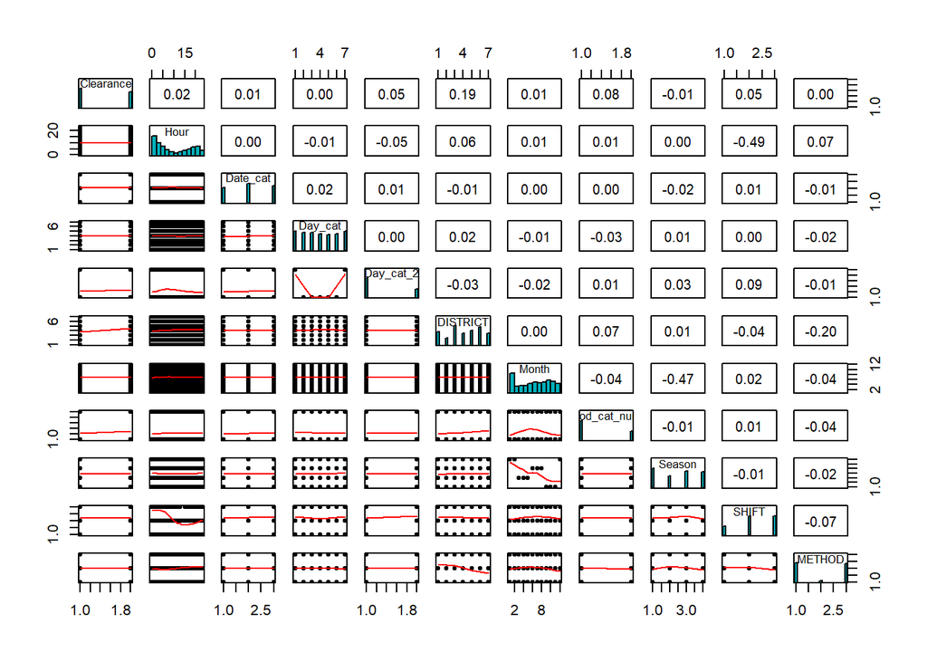

```r
pairs.panels(model_1_clean[,c(2,3:12)],
             method = "pearson",
             hist.col = "#00AFBB",
             density = FALSE,
             ellipses = FALSE
             )
```

**B-1. Below is Correlation plots with Census features and target**

Since we have 78 features, it is impossible all the relationship in one plot.

- So we checked each unit of 10 features (sorted by feature names) considering correlation with target (over 0.1) and checking the multicollinearity
- By above process, features were initially picked up for model.

This is the Correlation plot of the first unit 1 (10 features).

- Some features like `drove_alone_pct`,`Earning_mean`,`Earning_median_fmale_wk`appear to have relationship with target.
- But `Earning_mean`and `Earning_median_fmale_wk` have strong relationship (Corr > 0.7), which suggest choosing one for model.

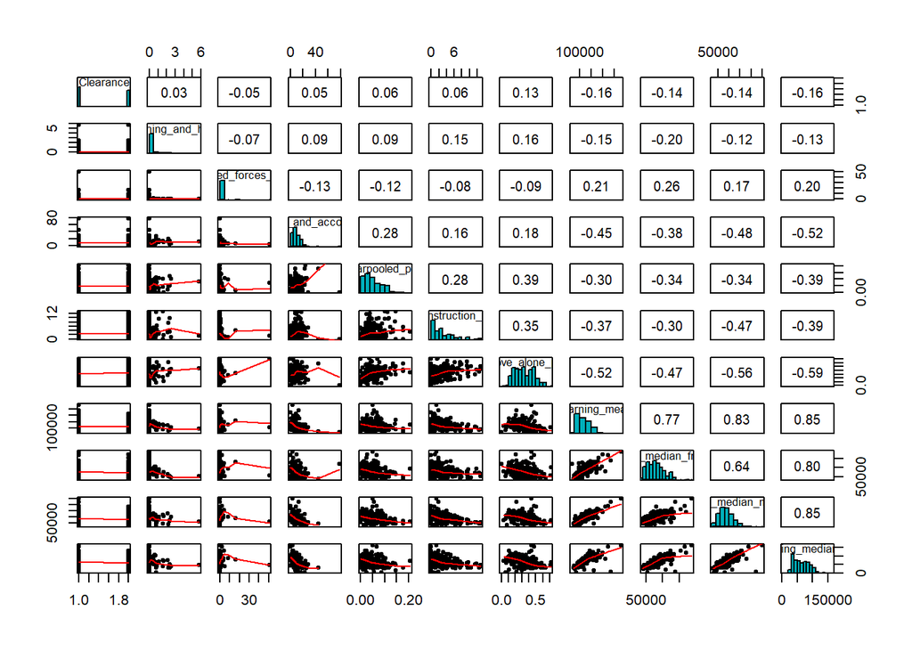

```r
pairs.panels(model_1_clean[,c(2,13:22)],
             method = "pearson",
             hist.col = "#00AFBB",
             density = FALSE,
             ellipses = FALSE
             )
```

This is the example of the unit 3 that also showed interaction betwwen similar income features.

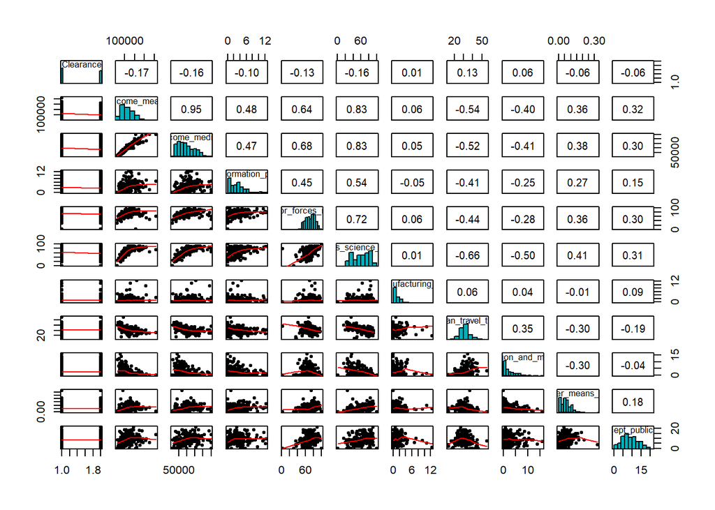

```r
pairs.panels(model_1_clean[,c(2,41:50)],
             method = "pearson",
             hist.col = "#00AFBB",
             density = FALSE,
             ellipses = FALSE
             )
```

This is the entire process of examining all census features (Code chunk has been inactive since it needs time to show).

```r
#pairs.panels(model_1_clean[,c(2,23:32)],
#             method = "pearson",
#             hist.col = "#00AFBB",
#             density = FALSE,
#             ellipses = FALSE
#             )

#pairs.panels(model_1_clean[,c(2,33:42)],
#             method = "pearson",
#             hist.col = "#00AFBB",
#             density = FALSE,
#             ellipses = FALSE
#             )

#pairs.panels(model_1_clean[,c(2,43:52)],
#             method = "pearson",
#             hist.col = "#00AFBB",
#             density = FALSE,
#             ellipses = FALSE
#             )

#pairs.panels(model_1_clean[,c(2,53:62)],
#             method = "pearson",
#             hist.col = "#00AFBB",
#             density = FALSE,
#             ellipses = FALSE
#             )

#pairs.panels(model_1_clean[,c(2,63:72)],
#             method = "pearson",
#             hist.col = "#00AFBB",
#             density = FALSE,
#             ellipses = FALSE
#             )

#pairs.panels(model_1_clean[,c(2,73:82)],
#             method = "pearson",
#             hist.col = "#00AFBB",
#             density = FALSE,
#             ellipses = FALSE
#             )

#pairs.panels(model_1_clean[,c(2,83:90)],
#             method = "pearson",
#             hist.col = "#00AFBB",
#             density = FALSE,
#             ellipses = FALSE
#             )
```

After going through entire process, 18 census features were initially picked.

```r
feat_cen <- c('drove_alone_pct','females_employed_rate','hs_10000_to_14999_pct','hs_100000_to_149999_pct','hs_15000_to_24999_pct','hs_150000_to_194999_pct','hs_200000__pct','hs_25000_to_34999_pct','hs_Less_than_10000_pct','Income_mean','labor_forces_rate','management_business_science_arts_occupations_pct','mean_travel_time','service_occupations_pct','Social_Security_income_mean','Transportation_and_warehousing_and_utilities_pct','unemployment_rate','worked_from_home_pct')

temp <- select(model_1_clean,feat_cen)
knitr::kable(summary(temp[,c(1:9)]), format = "markdown", caption="T2.Summary statistics (picked Census)_1")
```

T2.Summary statistics (picked Census)_1

|  | drove_alone_pct | females_employed_rate | hs_10000_to_14999_pct | hs_100000_to_149999_pct | hs_15000_to_24999_pct | hs_150000_to_194999_pct | hs_200000__pct | hs_25000_to_34999_pct | hs_Less_than_10000_pct |
| --- | --- | --- | --- | --- | --- | --- | --- | --- | --- |
|  | Min. :0.000 | Min. : 27.8 | Min. : 0.0 | Min. : 0.0 | Min. : 0.00 | Min. : 0.0 | Min. : 0.0 | Min. : 0.00 | Min. : 0.0 |
|  | 1st Qu.:0.220 | 1st Qu.: 85.2 | 1st Qu.: 1.2 | 1st Qu.: 9.7 | 1st Qu.: 2.11 | 1st Qu.: 4.6 | 1st Qu.: 4.9 | 1st Qu.: 2.69 | 1st Qu.: 3.6 |
|  | Median :0.318 | Median : 93.2 | Median : 3.3 | Median :14.3 | Median : 4.11 | Median : 8.6 | Median :16.3 | Median : 5.12 | Median : 7.6 |
|  | Mean :0.329 | Mean : 90.7 | Mean : 4.4 | Mean :14.6 | Mean : 5.74 | Mean : 9.8 | Mean :18.4 | Mean : 6.58 | Mean : 9.3 |
|  | 3rd Qu.:0.449 | 3rd Qu.: 97.4 | 3rd Qu.: 5.8 | 3rd Qu.:18.8 | 3rd Qu.: 8.46 | 3rd Qu.: 13.4 | 3rd Qu.:27.2 | 3rd Qu.: 8.96 | 3rd Qu.:13.6 |
|  | Max. :0.718 | Max. :100.0 | Max. :38.6 | Max. :34.0 | Max. :29.31 | Max. :100.0 | Max. :69.0 | Max. :28.85 | Max. :45.8 |
|  | NA’s :1 | NA’s :8 | NA’s :6 | NA’s :6 | NA’s :6 | NA’s :6 | NA’s :6 | NA’s :6 | NA’s :6 |

```r
knitr::kable(summary(temp[,c(10:18)]), format = "markdown", caption="T3.Summary statistics (picked Census)_2")
```

T3.Summary statistics (picked Census)_2

|  | Income_mean | labor_forces_rate | management_business_science_arts_occupations_pct | mean_travel_time | service_occupations_pct | Social_Security_income_mean | Transportation_and_warehousing_and_utilities_pct | unemployment_rate | worked_from_home_pct |
| --- | --- | --- | --- | --- | --- | --- | --- | --- | --- |
|  | Min. : 22795 | Min. : 3.2 | Min. : 1.0 | Min. :13.4 | Min. : 0.0 | Min. : 5436 | Min. : 0.00 | Min. : 0.0 | Min. :0.000 |
|  | 1st Qu.: 70911 | 1st Qu.: 63.1 | 1st Qu.: 41.9 | 1st Qu.:27.9 | 1st Qu.: 7.3 | 1st Qu.:12394 | 1st Qu.: 1.33 | 1st Qu.: 3.4 | 1st Qu.:0.123 |
|  | Median :112803 | Median : 72.2 | Median : 63.6 | Median :31.6 | Median :15.5 | Median :15172 | Median : 2.88 | Median : 7.5 | Median :0.182 |
|  | Mean :122422 | Mean : 71.7 | Mean : 60.8 | Mean :31.6 | Mean :16.5 | Mean :16250 | Mean : 4.03 | Mean : 9.5 | Mean :0.175 |
|  | 3rd Qu.:160622 | 3rd Qu.: 81.1 | 3rd Qu.: 79.4 | 3rd Qu.:34.4 | 3rd Qu.:24.2 | 3rd Qu.:19450 | 3rd Qu.: 6.09 | 3rd Qu.:13.9 | 3rd Qu.:0.241 |
|  | Max. :415621 | Max. :100.0 | Max. :100.0 | Max. :55.7 | Max. :78.4 | Max. :38324 | Max. :21.11 | Max. :67.8 | Max. :0.431 |
|  | NA’s :13 | NA’s :1 | NA’s :1 | NA’s :20 | NA’s :1 | NA’s :136 | NA’s :1 | NA’s :1 | NA’s :1 |

```r
# 34 features Initially picked by corrplots.

#cols <- c('drove_alone_pct','Earning_mean','Earning_median_fmale_wk','Earning_median_male_wk','Earning_median_wk','females_employed_rate','hs_10000_to_14999_pct','hs_100000_to_149999_pct','hs_15000_to_24999_pct','hs_150000_to_194999_pct','hs_200000__pct','hs_25000_to_34999_pct','hs_Less_than_10000_pct','Income_mean','Income_median','labor_forces_rate','management_business_science_arts_occupations_pct','mean_travel_time','pct_all_families_below_poverty','pct_all_families_related_children_below18_below_poverty','pct_all_people_18plus_below_poverty','pct_all_people_18to64_below_poverty','pct_all_people_below_poverty','pct_all_people_related_children_under18_below_poverty','pct_all_people_related_children_under18_below5_below_poverty','pct_all_people_under18_below_poverty','Production_transportation_and_material_moving_occupations_pct','Professional_scientific_and_management_and_administrative_and_waste_management_services_pct','Sales_and_office_occupations_pct','service_occupations_pct','Social_Security_income_mean','Transportation_and_warehousing_and_utilities_pct','unemployment_rate','worked_from_home_pct')

#temp <- select(model_1_clean,cols)

#cor_matrix <- cor(temp)
#high_cor_pairs <- which(cor_matrix > 0.8 & cor_matrix != 1, arr.ind = TRUE)
#high_cor_vars <- unique(c(high_cor_pairs[,1], high_cor_pairs[,2]))
#high_cor_matrix <- cor_matrix[high_cor_vars, high_cor_vars]
#high_cor_matrix
#corrplot(high_cor_matrix, method = "number")
```

There are some NAs but not much amount, so converted that with average value of each.

```r
temp <- temp %>%
               mutate_all(~ifelse(is.na(.), mean(., na.rm = TRUE), .))
summary(temp)
```

[output not shown]

B-2. Chart 9 is histogram of `Income_mean`(Census) by the target_Clearance_time groups (1: High, 0: Low)

- The short clearance time group (target =0) has a tendency of having a relatively high income compared with long clearance time group.

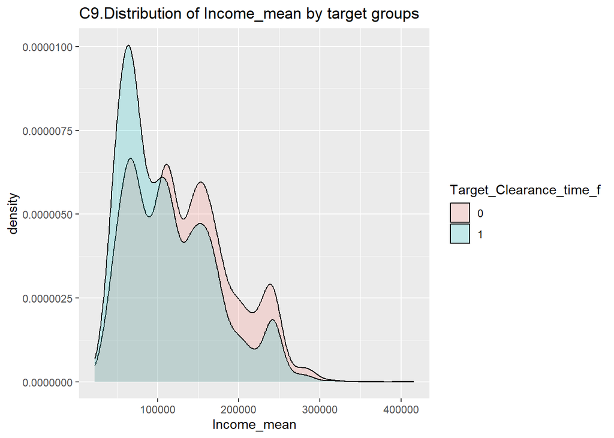

```r
#ggplot(model_1_clean, aes(Income_mean, fill = Target_Clearance_time_f)) +  geom_histogram(alpha = 0.5, aes(y = ..density..), position = 'identity')

ggplot(model_1_clean, aes(Income_mean, fill = Target_Clearance_time_f)) + geom_density(alpha = 0.2) + labs(title="C9.Distribution of Income_mean by target groups")
```

B-3. Chart 10 is histogram of `management_business_science_arts_occupations_pct`(Census) by the target_Clearance_time groups (1: High, 0: Low)

- The short clearance time group has a tendency of having a relatively high portion of occupations which fields are management, business, and science.

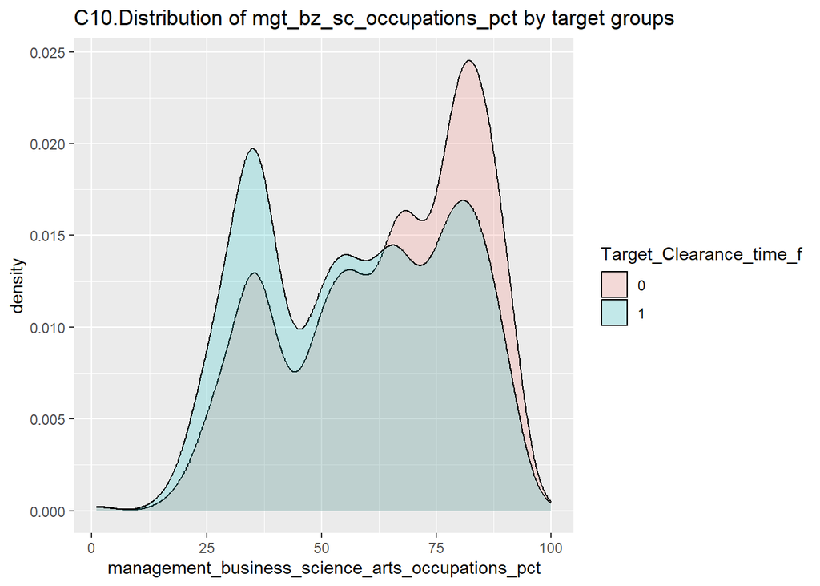

```r
#ggplot(model_1_clean, aes(management_business_science_arts_occupations_pct, fill = Target_Clearance_time_f)) +  geom_histogram(alpha = 0.5, aes(y = ..density..), position = 'identity')

ggplot(model_1_clean, aes(management_business_science_arts_occupations_pct, fill = Target_Clearance_time_f)) + geom_density(alpha = 0.2) + labs(title="C10.Distribution of mgt_bz_sc_occupations_pct by target groups")
```

```r
# Occupation is highly related with income
#temp_1 = model_1_clean[,c(41:45)]
#temp_1 <- temp_1 %>%
#               mutate_all(~ifelse(is.na(.), mean(., na.rm = TRUE), .))

#cor_cs= cor(temp_1)
#corrplot.mixed(cor_cs)
```

B-4. Chart 11 is histogram of `labor_forces_rate`(Census) by the target_Clearance_time groups (1: High, 0: Low)

- Interestingly, long clearance time robberies (target =1) are more concentrated on the boundary of proportion of working people below 60%, which reveals demographic environment affect the robbery difficulty.

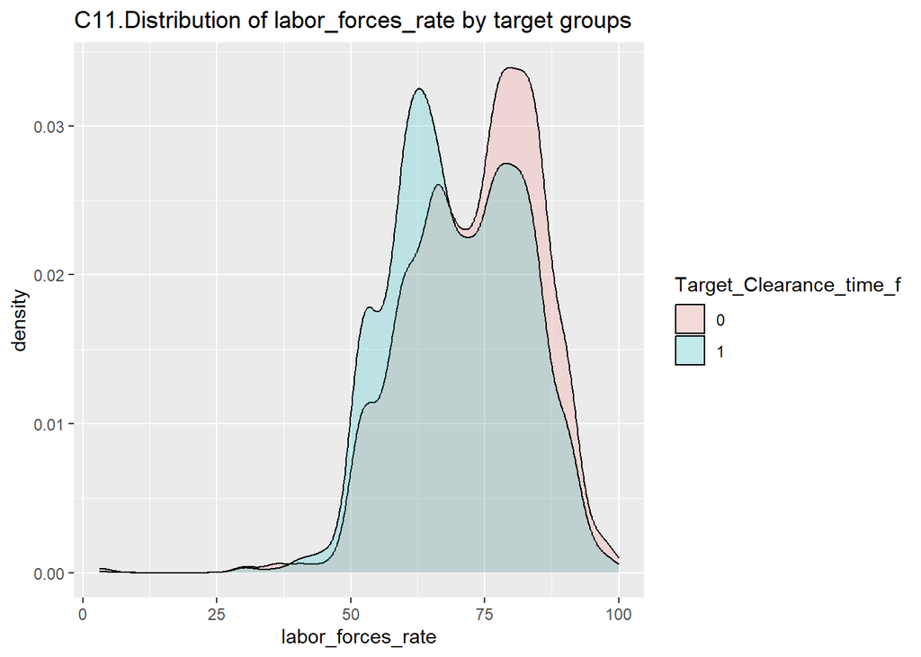

```r
#ggplot(model_1_clean, aes(labor_forces_rate, fill = Target_Clearance_time_f)) +  geom_histogram(alpha = 0.5, aes(y = ..density..), position = 'identity')

ggplot(model_1_clean, aes(labor_forces_rate, fill = Target_Clearance_time_f)) + geom_density(alpha = 0.2) + labs(title="C11.Distribution of labor_forces_rate by target groups")
```

**2. Model 2 (`Target_robbery_method`)**

- 1. Since `Target_robbery_method` is **Binary Quantitative variable**, plots that showing percentage of Gun method(target =1) ware showed for a few categorical features.
- 2. Similarly with model 1, histograms split by the target groups were used for checking relationship between interval variables and target.

Also, **Correlation plots** were used for feature selection of model 2.

```r
#plot <- ggplot(data=model_2_clean, aes(Target_robbery_method)) +
 # geom_histogram(col="darkgrey",
  #               fill="lightgrey",
   #              alpha = .7,bins = 30) +
  #labs(x="Target_robbery_method", y="Frequency") +
  #labs(title="Target_robbery_method frequency")
#plot
```

A-1. (EDA-categorical features) Chart 12 indicates `percentage of Gun method` per `DISTRICTS`.

- District seems to have linear relationship with target.

```r
#TWO var Groupby(mean of target by X category groups)
temp <-  model_2_clean %>% group_by(DISTRICT) %>%
                   summarise(avg = mean(as.numeric(Target_robbery_method), na.rm = TRUE),.groups = 'drop')  #Targe(%): mean( as.numeric(Target_Clearance_time)

arrange(temp, DISTRICT)
```

```
## # A tibble: 8 × 2
##   DISTRICT   avg
##      <int> <dbl>
## 1        1  1.38
## 2        2  1.31
## 3        3  1.37
## 4        4  1.48
## 5        5  1.51
## 6        6  1.62
## 7        7  1.60
## 8       NA  1.71
```

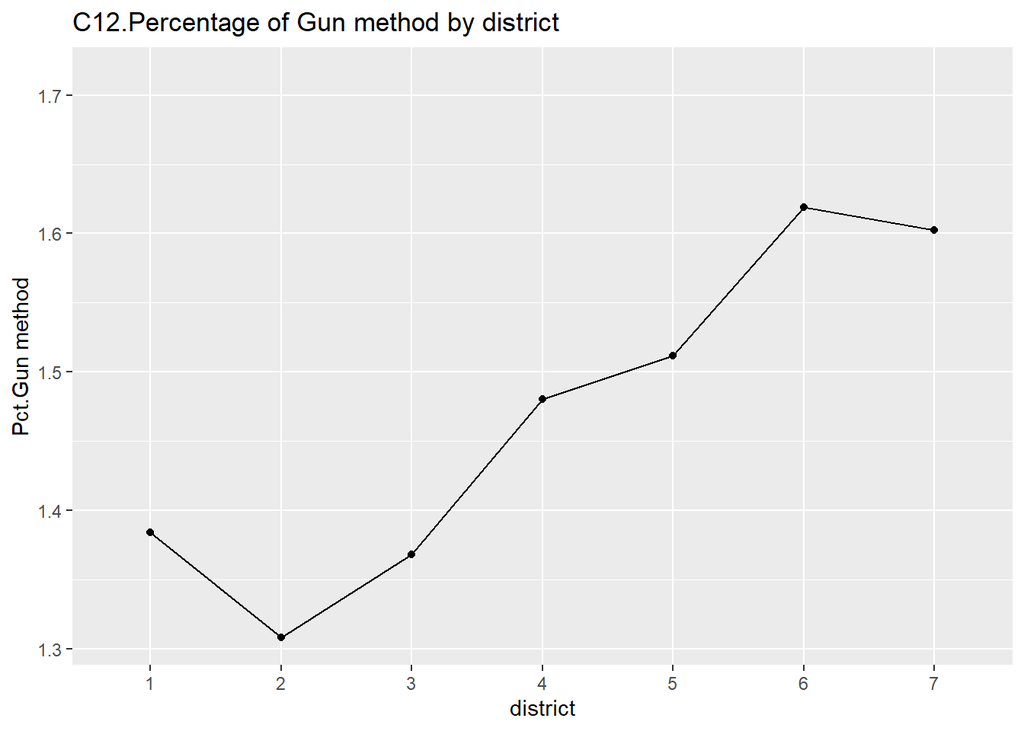

```r
temp_gr <- data.frame(temp)

#Make chart (scatter)
plot <- ggplot(temp_gr, aes(DISTRICT, avg)) + geom_line() + labs(x="district", y="Pct.Gun method") +
  labs(title="C12.Percentage of Gun method by district") + scale_x_discrete(limits=c("1","2","3","4","5","6","7")) + geom_point() #with 3-D: ggplot(temp_gr, aes(x, y, colour = Period_cat))

plot
```

A-2. Chart 13 indicates distribution of `percentage of Gun method` per `SHIFT`.

- We identified Gun robbery dramatically increased after the midnight.

```r
#TWO var Groupby(mean of target by X category groups)
temp <-  model_2_clean %>% group_by(SHIFT) %>%
                   summarise(avg = mean(as.numeric(Target_robbery_method), na.rm = TRUE),.groups = 'drop')  #Targe(%): mean( as.numeric(Target_Clearance_time)

arrange(temp, SHIFT)
```

```
## # A tibble: 3 × 2
##   SHIFT      avg
##   <fct>    <dbl>
## 1 DAY       1.45
## 2 EVENING   1.44
## 3 MIDNIGHT  1.54
```

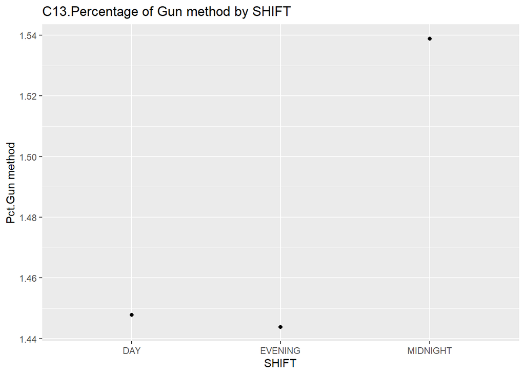

```r
temp_gr <- data.frame(temp)

#Make chart (scatter)
plot <- ggplot(temp_gr, aes(x = SHIFT, y = avg)) + geom_line() + labs(x="SHIFT", y="Pct.Gun method") +
  labs(title="C13.Percentage of Gun method by SHIFT") + geom_point() #with 3-D: ggplot(temp_gr, aes(x, y, colour = Period_cat))

plot
```

A-3. Chart 14 indicates distribution of `percentage of Gun method` per `Season`.

- Gun robbery has a tendency to increase since spring, high ratio in fall and winter.

```r
#TWO var Groupby(mean of target by X category groups)
temp <-  model_2_clean %>% group_by(Season) %>%
                   summarise(avg = mean(as.numeric(Target_robbery_method), na.rm = TRUE),.groups = 'drop')  #Targe(%): mean( as.numeric(Target_Clearance_time)

arrange(temp, Season)
```

```
## # A tibble: 4 × 2
##   Season   avg
##   <fct>  <dbl>
## 1 AUTUMN  1.51
## 2 SPRING  1.42
## 3 SUMMER  1.46
## 4 WINTER  1.53
```

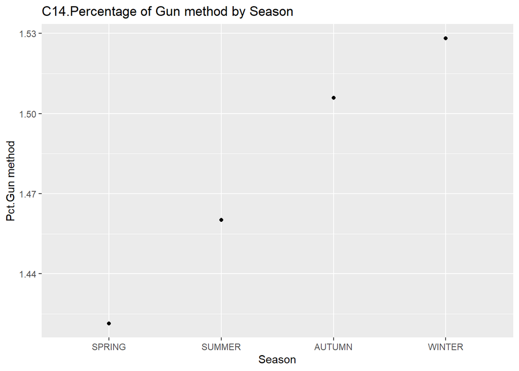

```r
temp_gr <- data.frame(temp)

#Make chart (scatter)
plot <- ggplot(temp_gr, aes(x = Season, y = avg)) + geom_line() + labs(x="Season", y="Pct.Gun method") +
  labs(title="C14.Percentage of Gun method by Season") + geom_point() + scale_x_discrete(limits=c("SPRING","SUMMER","AUTUMN","WINTER"))#with 3-D: ggplot(temp_gr, aes(x, y, colour = Period_cat))

plot
```

A-4. Chart 15 indicates distribution of `percentage of Gun method` per `Period_cat_num_2`.

- During Lockdown, Gun robberies are explicitly increased.

```r
#TWO var Groupby(mean of target by X category groups)
temp <-  model_2_clean %>% group_by(Period_cat_num_2) %>%
                   summarise(avg = mean(as.numeric(Target_robbery_method), na.rm = TRUE),.groups = 'drop')  #Targe(%): mean( as.numeric(Target_Clearance_time)

arrange(temp, Period_cat_num_2)
```

```
## # A tibble: 2 × 2
##   Period_cat_num_2   avg
##   <fct>            <dbl>
## 1 0                 1.47
## 2 1                 1.52
```

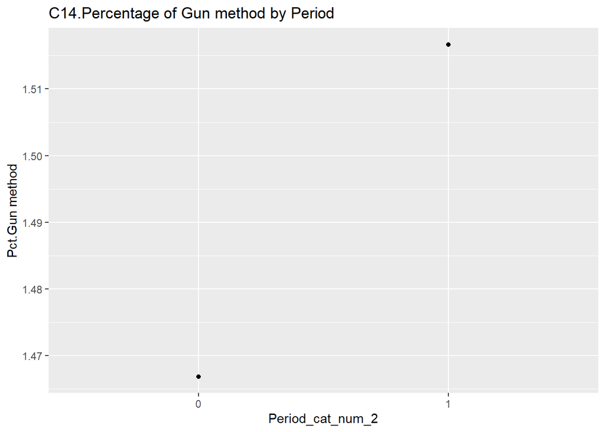

```r
temp_gr <- data.frame(temp)

#Make chart (scatter)
plot <- ggplot(temp_gr, aes(x = Period_cat_num_2, y = avg)) + geom_line() + labs(x="Period_cat_num_2", y="Pct.Gun method") +
  labs(title="C14.Percentage of Gun method by Period") + geom_point() #with 3-D: ggplot(temp_gr, aes(x, y, colour = Period_cat))

plot
```

**A-5. Below is Correlation plots with original features and target (with out Census)**

- **The first row means the relationship between features and target.**
- District, Period_cat_num_2, Hour, and SHIFT show relatively high correlation with `Target_robbery_method`.
- Day_cat,etc. are also have low correlation, but most origin variables will be initially used in the model 2.

```r
#str(model_2_clean)
```

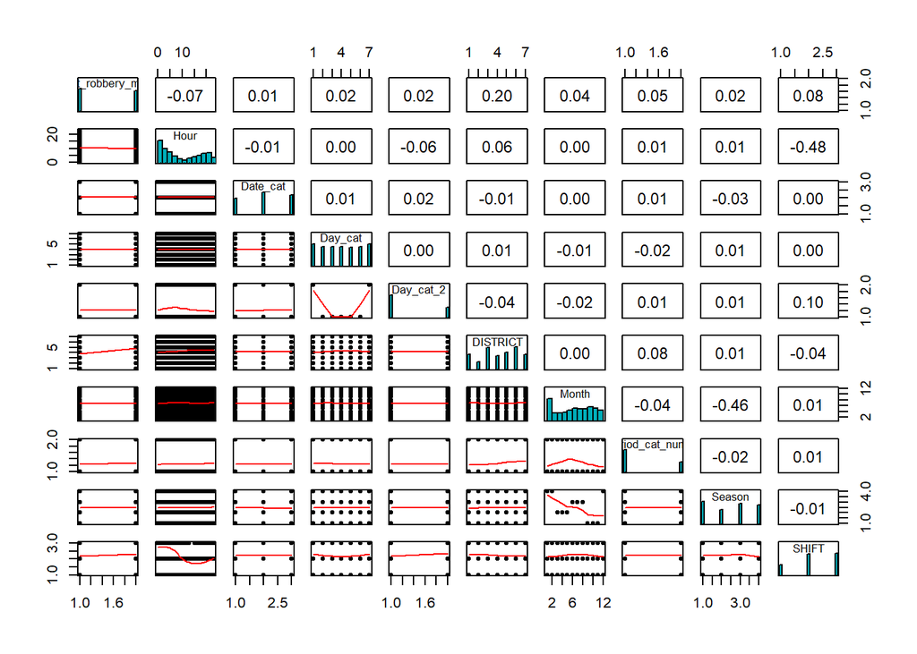

```r
pairs.panels(model_2_clean[,c(1,2:10)],
             method = "pearson",
             hist.col = "#00AFBB",
             density = FALSE,
             ellipses = FALSE
             )
```

**B-1. Below is Correlation plots with Census features and target**

- Similarly with model 1, Census features were initially picked up for model 2 by checking each unit of 10 Census features.
- Correlation with target and multicollinearity were considered for feature selection.

This is the Correlation plot of the first unit 1 (10 features).

```r
#str(model_2_clean)
```

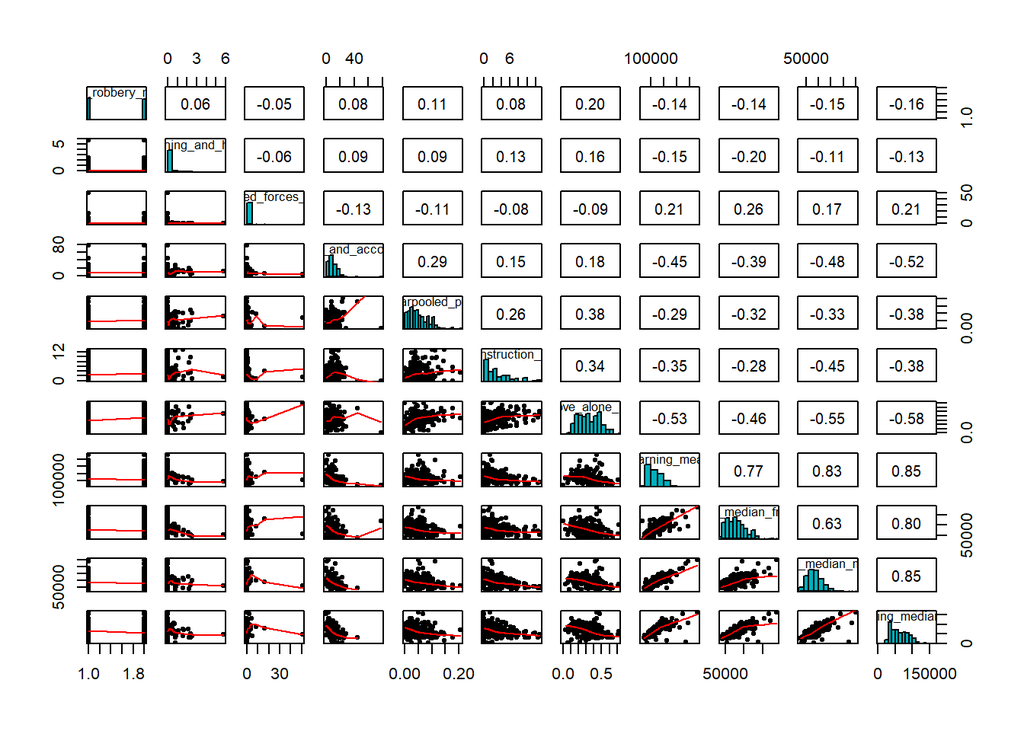

```r
pairs.panels(model_2_clean[,c(1,11:20)],
             method = "pearson",
             hist.col = "#00AFBB",
             density = FALSE,
             ellipses = FALSE
             )
```

This is the Correlation plot of the last unit.

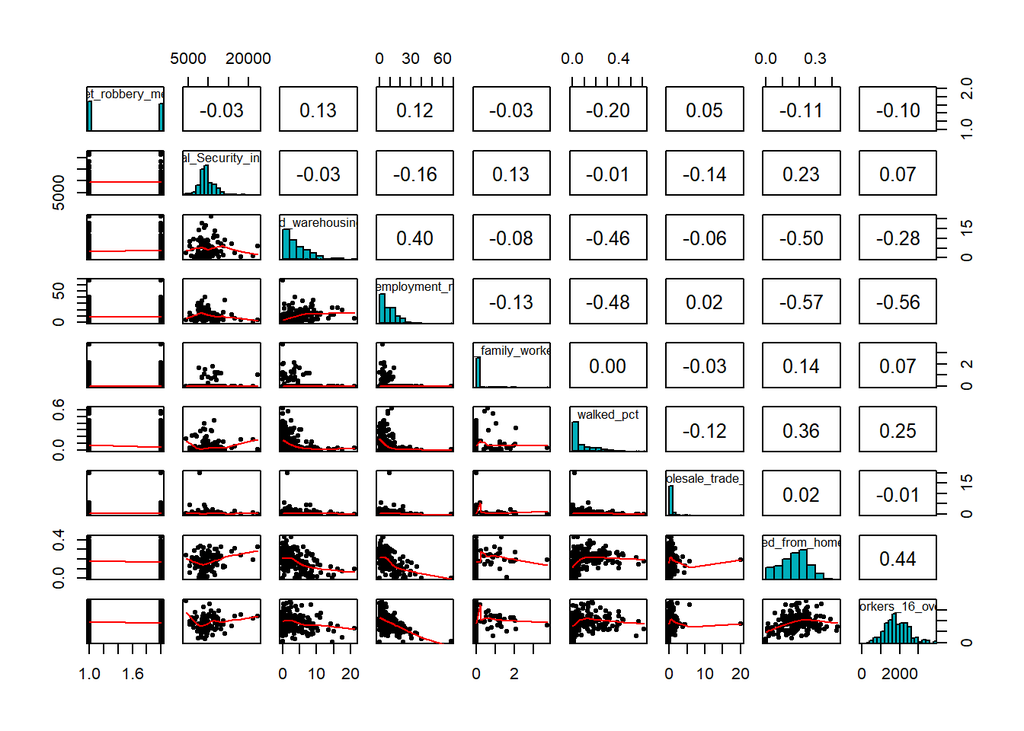

```r
pairs.panels(model_2_clean[,c(1,81:88)],
             method = "pearson",
             hist.col = "#00AFBB",
             density = FALSE,
             ellipses = FALSE
             )
```

This is the entire process of examining all census features (Code chunk has been inactive since it needs time to show).

```r
#pairs.panels(model_2_clean[,c(1,21:30)],
#             method = "pearson",
#             hist.col = "#00AFBB",
#             density = FALSE,
#             ellipses = FALSE
#             )

#pairs.panels(model_2_clean[,c(1,31:40)],
#             method = "pearson",
#             hist.col = "#00AFBB",
#             density = FALSE,
#             ellipses = FALSE
#             )

#pairs.panels(model_2_clean[,c(1,41:50)],
#             method = "pearson",
#             hist.col = "#00AFBB",
#             density = FALSE,
#             ellipses = FALSE
#             )

#pairs.panels(model_2_clean[,c(1,51:60)],
#             method = "pearson",
#             hist.col = "#00AFBB",
#             density = FALSE,
#             ellipses = FALSE
#             )

#pairs.panels(model_2_clean[,c(1,61:70)],
#             method = "pearson",
#             hist.col = "#00AFBB",
#             density = FALSE,
#             ellipses = FALSE
#             )

#pairs.panels(model_2_clean[,c(1,71:80)],
#             method = "pearson",
#             hist.col = "#00AFBB",
#             density = FALSE,
#             ellipses = FALSE
#             )


#pairs.panels(model_2_clean[,c(1,81:88)],
#             method = "pearson",
#             hist.col = "#00AFBB",
#             density = FALSE,
#             ellipses = FALSE
#             )
```

After going through entire process, 9 census features were picked.

```r
feat_cen <- c("drove_alone_pct", "Earning_mean", "Income_mean", "labor_forces_rate",  "mean_travel_time", "unemployment_rate","walked_pct","Sales_and_office_occupations_pct","public_transportation_pct")

temp <- select(model_2_clean,feat_cen)
knitr::kable(summary(temp), format = "markdown", caption="T4.Summary statistics (picked Census)")
```

T4.Summary statistics (picked Census)

|  | drove_alone_pct | Earning_mean | Income_mean | labor_forces_rate | mean_travel_time | unemployment_rate | walked_pct | Sales_and_office_occupations_pct | public_transportation_pct |
| --- | --- | --- | --- | --- | --- | --- | --- | --- | --- |
|  | Min. :0.000 | Min. : 30259 | Min. : 22795 | Min. : 3.2 | Min. :13.4 | Min. : 0.0 | Min. :0.000 | Min. : 0.0 | Min. :0.022 |
|  | 1st Qu.:0.223 | 1st Qu.: 78477 | 1st Qu.: 68432 | 1st Qu.: 62.4 | 1st Qu.:28.0 | 1st Qu.: 3.4 | 1st Qu.:0.009 | 1st Qu.: 9.1 | 1st Qu.:0.226 |
|  | Median :0.327 | Median :120746 | Median :109183 | Median : 71.9 | Median :31.8 | Median : 8.3 | Median :0.039 | Median :12.9 | Median :0.287 |
|  | Mean :0.334 | Mean :126248 | Mean :120253 | Mean : 71.4 | Mean :31.8 | Mean : 9.7 | Mean :0.088 | Mean :15.3 | Mean :0.295 |
|  | 3rd Qu.:0.454 | 3rd Qu.:167844 | 3rd Qu.:159189 | 3rd Qu.: 81.0 | 3rd Qu.:34.5 | 3rd Qu.:14.2 | 3rd Qu.:0.141 | 3rd Qu.:19.1 | 3rd Qu.:0.352 |
|  | Max. :0.718 | Max. :463037 | Max. :492607 | Max. :100.0 | Max. :55.7 | Max. :67.8 | Max. :0.617 | Max. :45.9 | Max. :0.990 |
|  | NA’s :2 | NA’s :17 | NA’s :17 | NA’s :2 | NA’s :23 | NA’s :2 | NA’s :2 | NA’s :2 | NA’s :2 |

**Overall, final features were chosen as follows.**

- Target_robbery_method ~ DISTRICT + Period_cat_num_2 + Season + Month +SHIFT + drove_alone_pct + Earning_mean + Income_mean + labor_forces_rate + mean_travel_time + unemployment_rate + walked_pct + Sales_and_office_occupations_pct + public_transportation_pct

**Finally checked the correlation between chosen features**

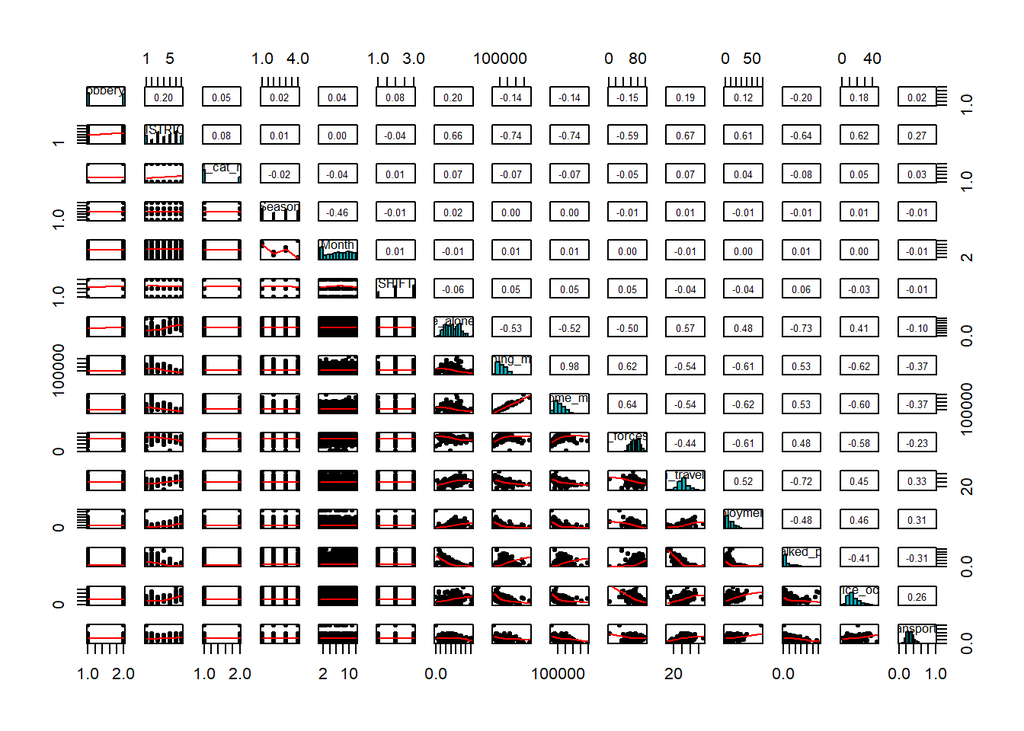

```r
pairs.panels(model_2_clean[,c("Target_robbery_method","DISTRICT","Period_cat_num_2","Season", "Month", "SHIFT", "drove_alone_pct", "Earning_mean", "Income_mean", "labor_forces_rate",  "mean_travel_time", "unemployment_rate","walked_pct","Sales_and_office_occupations_pct","public_transportation_pct")],
             method = "pearson",
             hist.col = "#00AFBB",
             density = FALSE,
             ellipses = FALSE
             )
```

B-2. Chart 16 is histogram of `drove_alone_pct`(Census) by the Target_robbery_method groups (1: GUN, 0: Others)

- District that has high portion of driving alone workers to commute has a tendency of having relatively high occurrence of Gun robbery compared to others.

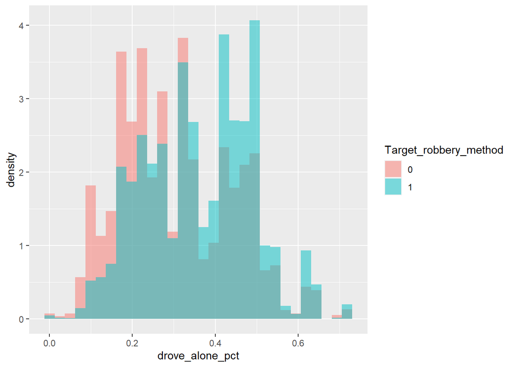

```r
ggplot(model_2_clean, aes(drove_alone_pct, fill = Target_robbery_method)) +  geom_histogram(alpha = 0.5, aes(y = ..density..), position = 'identity')
```

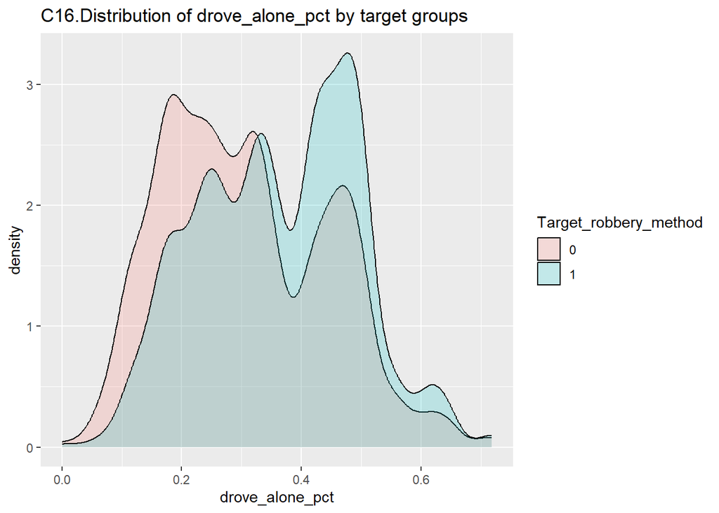

```r
ggplot(model_2_clean, aes(drove_alone_pct, fill = Target_robbery_method)) + geom_density(alpha = 0.2) + labs(title="C16.Distribution of drove_alone_pct by target groups")
```